# Lagged dependent variable and change score models

Wen Fan

2025-09-03

The research question we address is: Does general happiness predict work hours? The data set we will use comes from the General Social Surveys 2010 Panel, which can be downloaded [here](https://gss.norc.org/us/en/gss/get-the-data/stata.html)—titled “GSS Panel 2010–Sample Wave 3 (Release 6, March 2018)” in the “Panel Data Sets” section. For the purpose of this week, we will restrict our analyses to the first two waves.

### Install and load R packages

First, load the necessary libraries and the data.

```r
#install.packages(c('tidyverse', 'haven', 'corrplot', 'sjPlot', 'lavaan'))
library(tidyverse)
library(haven)
library(corrplot)
library(sjPlot)
library(lavaan)
```

```r
gss <- read_dta("/Users/wenfan/Library/CloudStorage/Dropbox/Longitudinal Data/GSS_panel2010w123_R6 - stata.dta")
```

### Descriptive analysis

Let’s take a look at the summary statistics for happiness and work hours, the first 10 rows of data to get a sense of its structure, and the correlation matrix and plot between variables.

Do the means and standard deviations look reasonable? How correlated are the Wave 1 and Wave 2 measures? Are there strong correlations between the predictor and the outcome?

```r
# Data cleaning
gss$happy_1 <- 4 - gss$happy_1
gss$happy_2 <- 4 - gss$happy_2

# Summary statistics
gss |> select("happy_1", "happy_2", "hrs1_1", "hrs1_2") |> summary()
```

```
##     happy_1         happy_2          hrs1_1          hrs1_2
##  Min.   :1.000   Min.   :1.000   Min.   : 1.00   Min.   : 1.00
##  1st Qu.:2.000   1st Qu.:2.000   1st Qu.:35.00   1st Qu.:32.00
##  Median :2.000   Median :2.000   Median :40.00   Median :40.00
##  Mean   :2.108   Mean   :2.139   Mean   :41.36   Mean   :39.87
##  3rd Qu.:3.000   3rd Qu.:3.000   3rd Qu.:50.00   3rd Qu.:50.00
##  Max.   :3.000   Max.   :3.000   Max.   :89.00   Max.   :89.00
##  NA's   :5       NA's   :494     NA's   :905     NA's   :1113
```

```r
# First 10 rows of data
head(gss[, c("happy_1", "happy_2", "hrs1_1", "hrs1_2")], 10)
```

```
## # A tibble: 10 × 4
##    happy_1 happy_2 hrs1_1      hrs1_2
##      <dbl>   <dbl> <dbl+lbl>   <dbl+lbl>
##  1       2       2    55          43
##  2       1       2    45          45
##  3       1       1 NA(i) [IAP] NA(i) [IAP]
##  4       1       1 NA(i) [IAP] NA(i) [IAP]
##  5       3      NA NA(i) [IAP] NA(i) [IAP]
##  6       2       2 NA(i) [IAP] NA(i) [IAP]
##  7       2       1    45          45
##  8       2       1 NA(i) [IAP] NA(i) [IAP]
##  9       3       2    40          37
## 10       3       3    48          60
```

```r
# Correlation matrix
(cor_matrix <- gss |> select("happy_1", "happy_2", "hrs1_1", "hrs1_2") |> cor(use = "complete.obs"))
```

```
##            happy_1    happy_2     hrs1_1     hrs1_2
## happy_1 1.00000000 0.48580297 0.01726399 0.03069116
## happy_2 0.48580297 1.00000000 0.04605466 0.08749931
## hrs1_1  0.01726399 0.04605466 1.00000000 0.48588394
## hrs1_2  0.03069116 0.08749931 0.48588394 1.00000000
```

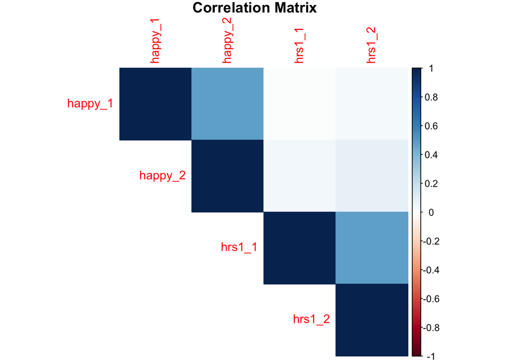

```r
# Correlation plot
corrplot(cor_matrix, method = "color", type = "upper",
         title = "Correlation Matrix", mar = c(0, 0, 1, 0))
```

### Lagged dependent variable model

Does general happiness at Wave 1 predict work hours at Wave 2, controlling for work hours?

How should we interpret the coefficients for the lagged dependent variable (LDV) and general happiness? How much of the variance is explained?

```r
# Basic LDV model
ldv1 <- lm(hrs1_2 ~ hrs1_1 + happy_1, data = gss)
summary(ldv1)
```

```
##
## Call:
## lm(formula = hrs1_2 ~ hrs1_1 + happy_1, data = gss)
##
## Residuals:
##     Min      1Q  Median      3Q     Max
## -50.998  -5.125   0.415   6.224  49.415
##
## Coefficients:
##             Estimate Std. Error t value Pr(>|t|)
## (Intercept) 17.55193    2.25666   7.778 2.45e-14 ***
## hrs1_1       0.52383    0.03447  15.195  < 2e-16 ***
## happy_1      0.53998    0.77336   0.698    0.485
## ---
## Signif. codes:  0 '***' 0.001 '**' 0.01 '*' 0.05 '.' 0.1 ' ' 1
##
## Residual standard error: 13.08 on 748 degrees of freedom
##   (1293 observations deleted due to missingness)
## Multiple R-squared:  0.2366, Adjusted R-squared:  0.2345
## F-statistic: 115.9 on 2 and 748 DF,  p-value: < 2.2e-16
```

```r
# Calculate change in R-squared after adding baseline happiness
base <- lm(hrs1_2 ~ hrs1_1, data = gss)
summary(base)
```

```
##
## Call:
## lm(formula = hrs1_2 ~ hrs1_1, data = gss)
##
## Residuals:
##     Min      1Q  Median      3Q     Max
## -51.658  -4.924   0.320   6.125  49.320
##
## Coefficients:
##             Estimate Std. Error t value Pr(>|t|)
## (Intercept) 18.70183    1.53290   12.20   <2e-16 ***
## hrs1_1       0.52445    0.03439   15.25   <2e-16 ***
## ---
## Signif. codes:  0 '***' 0.001 '**' 0.01 '*' 0.05 '.' 0.1 ' ' 1
##
## Residual standard error: 13.06 on 751 degrees of freedom
##   (1291 observations deleted due to missingness)
## Multiple R-squared:  0.2364, Adjusted R-squared:  0.2354
## F-statistic: 232.5 on 1 and 751 DF,  p-value: < 2.2e-16
```

```r
r2_change <- summary(ldv1)$r.squared - summary(base)$r.squared
cat("R-squared change from adding happiness:", round(r2_change, 4))
```

```
## R-squared change from adding happiness: 2e-04
```

We can continue adding other covariates.

```r
ldv2 <- update(ldv1, . ~ . + factor(race_1))
summary(ldv2)
```

```
##
## Call:
## lm(formula = hrs1_2 ~ hrs1_1 + happy_1 + factor(race_1), data = gss)
##
## Residuals:
##     Min      1Q  Median      3Q     Max
## -50.782  -5.249   0.606   6.306  49.606
##
## Coefficients:
##                 Estimate Std. Error t value Pr(>|t|)
## (Intercept)      17.1877     2.2945   7.491 1.94e-13 ***
## hrs1_1            0.5249     0.0345  15.213  < 2e-16 ***
## happy_1           0.6064     0.7762   0.781    0.435
## factor(race_1)2   0.1087     1.4213   0.076    0.939
## factor(race_1)3   2.3018     1.8807   1.224    0.221
## ---
## Signif. codes:  0 '***' 0.001 '**' 0.01 '*' 0.05 '.' 0.1 ' ' 1
##
## Residual standard error: 13.09 on 746 degrees of freedom
##   (1293 observations deleted due to missingness)
## Multiple R-squared:  0.2381, Adjusted R-squared:  0.234
## F-statistic: 58.29 on 4 and 746 DF,  p-value: < 2.2e-16
```

Let’s then fit a cross-lagged panel model. Note that happiness is not a continuous variable, so strictly speaking, OLS is not the best model. I am using it here for simplicity.

The model fits perfectly (CFI = 1.000, RMSEA = 0.000) because it is saturated. It has 0 degrees of freedom, meaning it uses all available information and cannot be wrong.

What do we conclude? Work hours and happiness do not predict each other over time in this sample. Both variables show similar persistence ($~50\%$), suggesting room for change over time.

```r
# Model specification
clpm_model <- '
  # Cross-lagged effects
  hrs1_2 ~ cross_happy*happy_1 + stable_hrs * hrs1_1
  happy_2 ~ cross_hrs*hrs1_1 + stable_happy * happy_1

  # Correlations at W1: "~~" correlation/covariance
  hrs1_1 ~~ happy_1

  # Correlated residuals at W2: after accounting for W1 predictors, W2 variables might still be related due to unmeasured factors
  hrs1_2 ~~ happy_2

  # Means (intercepts): "~ 1" estimates the intercept/mean, usually included for completeness
  hrs1_2 ~ 1
  happy_2 ~ 1
'

# Fit the model
clpm_fit <- sem(clpm_model, data = gss)

# Display results
summary(clpm_fit, fit.measures = TRUE, standardized = TRUE)
```

```
## lavaan 0.6-19 ended normally after 39 iterations
##
##   Estimator                                         ML
##   Optimization method                           NLMINB
##   Number of model parameters                        14
##
##                                                   Used       Total
##   Number of observations                           751        2044
##
## Model Test User Model:
##
##   Test statistic                                 0.000
##   Degrees of freedom                                 0
##
## Model Test Baseline Model:
##
##   Test statistic                               410.329
##   Degrees of freedom                                 6
##   P-value                                        0.000
##
## User Model versus Baseline Model:
##
##   Comparative Fit Index (CFI)                    1.000
##   Tucker-Lewis Index (TLI)                       1.000
##
## Loglikelihood and Information Criteria:
##
##   Loglikelihood user model (H0)              -7322.353
##   Loglikelihood unrestricted model (H1)             NA
##
##   Akaike (AIC)                               14672.707
##   Bayesian (BIC)                             14737.406
##   Sample-size adjusted Bayesian (SABIC)      14692.951
##
## Root Mean Square Error of Approximation:
##
##   RMSEA                                          0.000
##   90 Percent confidence interval - lower         0.000
##   90 Percent confidence interval - upper         0.000
##   P-value H_0: RMSEA <= 0.050                       NA
```

[output cut: 26 more lines]

```
##    .happy_2           0.491    0.252    1.945    0.052    0.491    0.071
##
## Intercepts:
##                    Estimate  Std.Err  z-value  P(>|z|)   Std.lv  Std.all
##    .hrs1_2           17.552    2.252    7.793    0.000   17.552    1.175
##    .happy_2           1.091    0.091   11.969    0.000    1.091    1.803
##     happy_1           2.170    0.023   96.353    0.000    2.170    3.516
##     hrs1_1           42.353    0.505   83.814    0.000   42.353    3.058
##
## Variances:
##                    Estimate  Std.Err  z-value  P(>|z|)   Std.lv  Std.all
##    .hrs1_2          170.426    8.795   19.378    0.000  170.426    0.763
##    .happy_2           0.279    0.014   19.378    0.000    0.279    0.763
##     happy_1           0.381    0.020   19.378    0.000    0.381    1.000
##     hrs1_1          191.768    9.896   19.378    0.000  191.768    1.000
```

### Change score model

What predicts the amount of change in work hours?

How should we interpret the coefficient for happiness? How much of the variance in change is explained?

```r
# Basic change score model
gss$change_wh <- gss$hrs1_2 - gss$hrs1_1
cs1 <- lm(change_wh ~ happy_1, data = gss)

summary(cs1)
```

```
##
## Call:
## lm(formula = change_wh ~ happy_1, data = gss)
##
## Residuals:
##     Min      1Q  Median      3Q     Max
## -69.140  -6.496   1.504   6.148  61.504
##
## Coefficients:
##             Estimate Std. Error t value Pr(>|t|)
## (Intercept)  -2.2151     1.9534  -1.134    0.257
## happy_1       0.3556     0.8657   0.411    0.681
##
## Residual standard error: 14.64 on 749 degrees of freedom
##   (1293 observations deleted due to missingness)
## Multiple R-squared:  0.0002252,  Adjusted R-squared:  -0.00111
## F-statistic: 0.1687 on 1 and 749 DF,  p-value: 0.6814
```

Note the mathematical equivalence to the LDV model if we include a lagged dependent variable in the change score model–pay attention to the predictor coefficients.

```r
# What if we add the lagged dependent variable?
cs2 <- update(cs1, . ~ . + hrs1_1)

summary(cs2)
```

```
##
## Call:
## lm(formula = change_wh ~ happy_1 + hrs1_1, data = gss)
##
## Residuals:
##     Min      1Q  Median      3Q     Max
## -50.998  -5.125   0.415   6.224  49.415
##
## Coefficients:
##             Estimate Std. Error t value Pr(>|t|)
## (Intercept) 17.55193    2.25666   7.778 2.45e-14 ***
## happy_1      0.53998    0.77336   0.698    0.485
## hrs1_1      -0.47617    0.03447 -13.812  < 2e-16 ***
## ---
## Signif. codes:  0 '***' 0.001 '**' 0.01 '*' 0.05 '.' 0.1 ' ' 1
##
## Residual standard error: 13.08 on 748 degrees of freedom
##   (1293 observations deleted due to missingness)
## Multiple R-squared:  0.2034, Adjusted R-squared:  0.2013
## F-statistic:  95.5 on 2 and 748 DF,  p-value: < 2.2e-16
```

```r
tab_model(ldv1, cs2)
```

|  | hrs1_2: NUMBER OF HOURS WORKED LAST WEEK |  |  | change_wh |  |  |
| --- | --- | --- | --- | --- | --- | --- |
| Predictors | Estimates | CI | p | Estimates | CI | p |
| (Intercept) | 17.55 | 13.12 – 21.98 | **<0.001** | 17.55 | 13.12 – 21.98 | **<0.001** |
| hrs1_1: NUMBER OF HOURS WORKED LAST WEEK | 0.52 | 0.46 – 0.59 | **<0.001** | -0.48 | -0.54 – -0.41 | **<0.001** |
| happy_1 | 0.54 | -0.98 – 2.06 | 0.485 | 0.54 | -0.98 – 2.06 | 0.485 |
| Observations | 751 |  |  | 751 |  |  |
| R<sup>2</sup> / R<sup>2</sup> adjusted | 0.237 / 0.235 |  |  | 0.203 / 0.201 |  |  |

Diagnostic plots for both models—check for patterns that might indicate issues with model fit or assumptions.

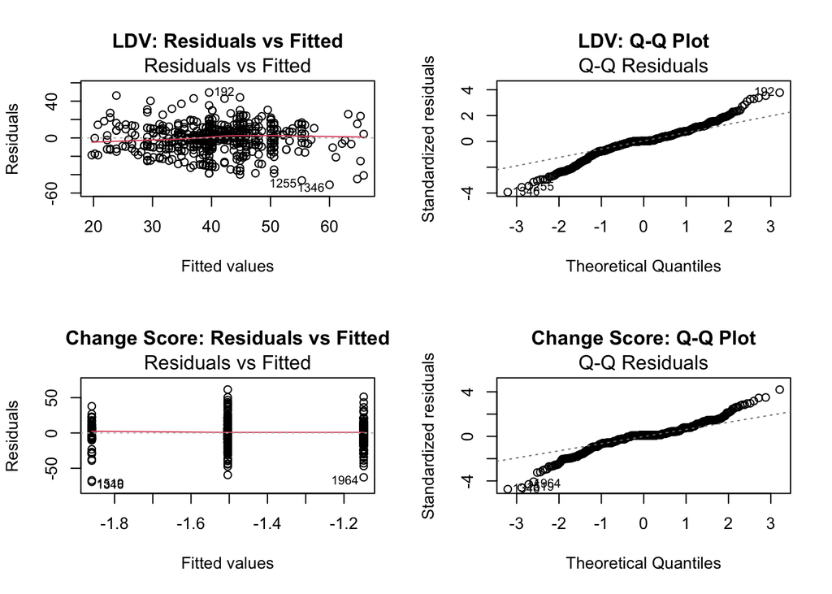

```r
par(mfrow = c(2, 2))

# Residuals vs fitted for LDV model
plot(ldv1, which = 1, main = "LDV: Residuals vs Fitted")
plot(ldv1, which = 2, main = "LDV: Q-Q Plot")

# Residuals vs fitted for change score model
plot(cs1, which = 1, main = "Change Score: Residuals vs Fitted")
plot(cs1, which = 2, main = "Change Score: Q-Q Plot")
```